# Biostat 203B Homework 5- Stacking

Due Mar 22 @ 11:59PM

Author

Yue Shu, 106332516

## Predicting ICU duration

Using the ICU cohort `mimiciv_icu_cohort.rds` you built in Homework 4, develop at least three machine learning approaches (logistic regression with enet regularization, random forest, boosting, SVM, MLP, etc) plus a model stacking approach for predicting whether a patient’s ICU stay will be longer than 2 days. You should use the `los_long` variable as the outcome. You algorithms can use patient demographic information (gender, age at ICU `intime`, marital status, race), ICU admission information (first care unit), the last lab measurements before the ICU stay, and first vital measurements during ICU stay as features. You are welcome to use any feature engineering techniques you think are appropriate; but make sure to not use features that are not available at an ICU stay’s `intime`. For instance, `last_careunit` cannot be used in your algorithms.

1. Data preprocessing and feature engineering.
2. Partition data into 50% training set and 50% test set. Stratify partitioning according to `los_long`. For grading purpose, sort the data by `subject_id`, `hadm_id`, and `stay_id` and use the seed `203` for the initial data split. Below is the sample code.

```r
set.seed(203)

# sort
mimic_icu_cohort <- mimic_icu_cohort |>
  arrange(subject_id, hadm_id, stay_id)

data_split <- initial_split(
  mimiciv_icu_cohort,
  # stratify by los_long
  strata = "los_long",
  prop = 0.5
  )
```

3. Train and tune the models using the training set.
4. Compare model classification performance on the test set. Report both the area under ROC curve and accuracy for each machine learning algorithm and the model stacking. Interpret the results. What are the most important features in predicting long ICU stays? How do the models compare in terms of performance and interpretability?

**Answer:**

```r
library(GGally)
library(gtsummary)
library(tidyverse)
library(tidymodels)
library(glmnet)
library(ranger)

# load data
mimic_icu_cohort <- readRDS("mimic_icu_cohort.rds")

# data preprocessing
mimic_icu_cohort <- mimic_icu_cohort %>%
  mutate(los_long = ifelse(los > 2, "long", "short"))%>%
  select(subject_id, hadm_id, stay_id,
         first_careunit,gender,age_intime,
         los_long,marital_status,race,
         "Bicarbonate",Creatinine,
         Potassium,Sodium,Chloride,
         Hematocrit,"White Blood Cells",
         Glucose,"Heart Rate","Respiratory Rate",
         "Temperature Fahrenheit",
         "Non Invasive Blood Pressure diastolic",
         "Non Invasive Blood Pressure systolic")

tbl_summary(mimic_icu_cohort,
  by = los_long
)
```

| **Characteristic** | **long**, N = 35,131<sup>1</sup> | **short**, N = 38,050<sup>1</sup> |
| --- | --- | --- |
| subject_id | 14,995,832 (12,498,337, 17,496,102) | 15,002,798 (12,488,949, 17,523,219) |
| hadm_id | 24,995,222 (22,499,999, 27,473,223) | 24,949,943 (22,469,194, 27,466,877) |
| stay_id | 34,960,130 (32,470,375, 37,471,693) | 35,026,375 (32,509,262, 37,504,248) |
| first_careunit |  |  |
| Cardiac Vascular Intensive Care Unit (CVICU) | 5,755 (16%) | 5,827 (15%) |
| Coronary Care Unit (CCU) | 4,194 (12%) | 4,117 (11%) |
| Medical Intensive Care Unit (MICU) | 7,116 (20%) | 8,782 (23%) |
| Medical/Surgical Intensive Care Unit (MICU/SICU) | 5,586 (16%) | 7,147 (19%) |
| Surgical Intensive Care Unit (SICU) | 5,507 (16%) | 5,654 (15%) |
| Trauma SICU (TSICU) | 4,228 (12%) | 4,464 (12%) |
| Other | 2,745 (7.8%) | 2,059 (5.4%) |
| gender |  |  |
| F | 15,349 (44%) | 17,014 (45%) |
| M | 19,782 (56%) | 21,036 (55%) |
| age_intime | 67 (56, 78) | 65 (53, 77) |
| marital_status |  |  |
| DIVORCED | 2,561 (7.9%) | 2,843 (8.0%) |
| MARRIED | 15,784 (49%) | 16,984 (48%) |
| SINGLE | 9,683 (30%) | 11,175 (31%) |
| WIDOWED | 4,339 (13%) | 4,699 (13%) |
| Unknown | 2,764 | 2,349 |
| race |  |  |
| Other | 5,596 (16%) | 5,160 (14%) |
| ASIAN | 1,007 (2.9%) | 1,148 (3.0%) |
| BLACK | 3,649 (10%) | 4,311 (11%) |
| HISPANIC | 1,249 (3.6%) | 1,492 (3.9%) |
| WHITE | 23,630 (67%) | 25,939 (68%) |
| Bicarbonate | 24.0 (21.0, 27.0) | 25.0 (22.0, 27.0) |
| Unknown | 4,780 | 4,270 |
| Creatinine | 1.00 (0.80, 1.60) | 1.00 (0.80, 1.40) |
| Unknown | 3,171 | 2,599 |
| Potassium | 4.20 (3.80, 4.70) | 4.20 (3.80, 4.60) |
| Unknown | 4,712 | 4,189 |
| Sodium | 138.0 (135.0, 141.0) | 139.0 (136.0, 141.0) |
| Unknown | 4,698 | 4,174 |
| Chloride | 102 (98, 105) | 102 (98, 105) |
| Unknown | 4,708 | 4,175 |
| Hematocrit | 35 (29, 40) | 36 (30, 40) |
| Unknown | 2,781 | 2,236 |
| White Blood Cells | 9.7 (7.0, 13.8) | 9.0 (6.6, 12.6) |
| Unknown | 2,822 | 2,272 |
| Glucose | 122 (100, 159) | 118 (98, 153) |
| Unknown | 4,817 | 4,282 |
| Heart Rate | 88 (77, 102) | 85 (74, 98) |
| Unknown | 1 | 69 |
| Respiratory Rate | 20 (16, 24) | 19 (16, 23) |
| Unknown | 10 | 131 |
| Temperature Fahrenheit | 98.20 (97.60, 98.80) | 98.10 (97.60, 98.60) |
| Unknown | 170 | 1,065 |
| Non Invasive Blood Pressure diastolic | 67 (57, 80) | 69 (59, 81) |
| Unknown | 245 | 735 |
| Non Invasive Blood Pressure systolic | 120 (102, 139) | 123 (107, 140) |
| Unknown | 242 | 735 |

<sup>1</sup> Median (IQR); n (%)

```r
# split data
set.seed(203)
mimic_icu_cohort <- mimic_icu_cohort |>
  arrange(subject_id, hadm_id, stay_id)

data_split <- initial_split(
  mimic_icu_cohort,
  strata = "los_long",
  prop = 0.5
  )

mimic_other <- training(data_split)
dim(mimic_other)
```

```
[1] 36590    22
```

```r
mimic_test <- testing(data_split)
dim(mimic_test)
```

```
[1] 36591    22
```

Stacking

```r
# Load libraries
library(GGally)
library(gtsummary)
library(ranger)
library(stacks)
library(tidyverse)
library(tidymodels)
library(doParallel)
logit_fit <- readRDS("logistic_regression_model.rds")
rf_fit <- readRDS("Random Forest.rds")
gb_fit <- readRDS("Boosting.rds")

mimic_model_st <-
  stacks() |>
  add_candidates(logit_fit) |>
  add_candidates(rf_fit) |>
  add_candidates(gb_fit) |>
  blend_predictions(
    penalty = 10^(-6:2),
    metrics = c("roc_auc")
  ) |>
  fit_members()
```

[output not shown]

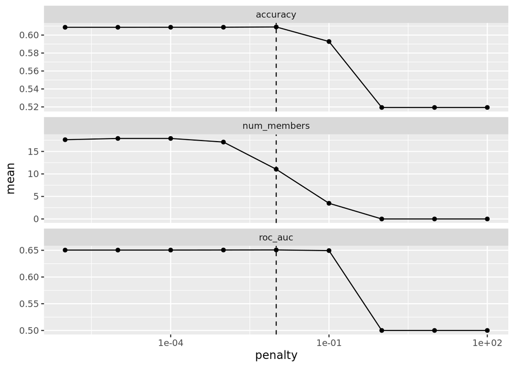

```r
autoplot(mimic_model_st)
```

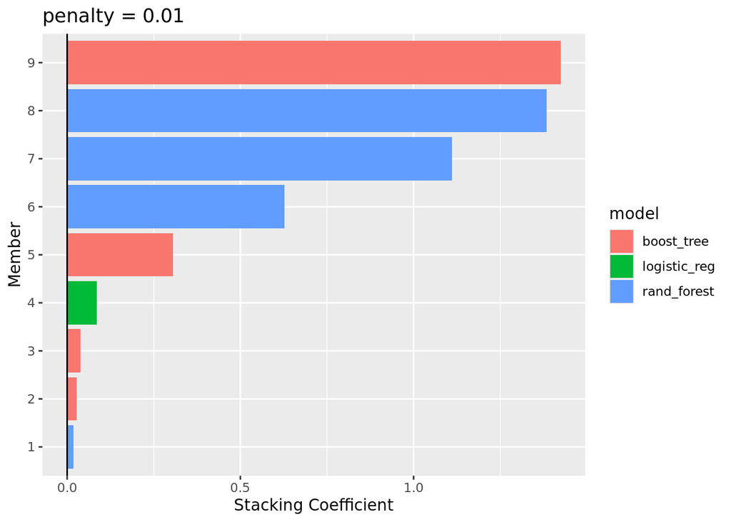

```r
autoplot(mimic_model_st, type = "weights")
```

```r
collect_parameters(mimic_model_st, "rf_fit")
```

```
# A tibble: 15 × 5
   member       mtry trees terms                     coef
   <chr>       <int> <int> <chr>                    <dbl>
 1 rf_fit_1_01     1   500 .pred_short_rf_fit_1_01 0
 2 rf_fit_1_02     1   587 .pred_short_rf_fit_1_02 0
 3 rf_fit_1_03     1   675 .pred_short_rf_fit_1_03 0
 4 rf_fit_1_04     1   762 .pred_short_rf_fit_1_04 0
 5 rf_fit_1_05     1   850 .pred_short_rf_fit_1_05 0
 6 rf_fit_1_06     2   500 .pred_short_rf_fit_1_06 0
 7 rf_fit_1_07     2   587 .pred_short_rf_fit_1_07 0
 8 rf_fit_1_08     2   675 .pred_short_rf_fit_1_08 0
 9 rf_fit_1_09     2   762 .pred_short_rf_fit_1_09 1.38
10 rf_fit_1_10     2   850 .pred_short_rf_fit_1_10 0.627
11 rf_fit_1_11     3   500 .pred_short_rf_fit_1_11 0
12 rf_fit_1_12     3   587 .pred_short_rf_fit_1_12 1.11
13 rf_fit_1_13     3   675 .pred_short_rf_fit_1_13 0
14 rf_fit_1_14     3   762 .pred_short_rf_fit_1_14 0
15 rf_fit_1_15     3   850 .pred_short_rf_fit_1_15 0.0177
```

```r
mimic_pred0 <- mimic_test %>%
  bind_cols(predict(mimic_model_st, ., type = "prob")) %>%
  print(width = Inf)
```

```
# A tibble: 36,591 × 24
   subject_id  hadm_id  stay_id first_careunit
        <int>    <int>    <int> <fct>
 1   10000980 26913865 39765666 Medical Intensive Care Unit (MICU)
 2   10001884 26184834 37510196 Medical Intensive Care Unit (MICU)
 3   10002155 20345487 32358465 Medical Intensive Care Unit (MICU)
 4   10002155 28994087 31090461 Medical/Surgical Intensive Care Unit (MICU/SICU)
 5   10002348 22725460 32610785 Other
 6   10002428 20321825 34807493 Medical Intensive Care Unit (MICU)
 7   10002428 23473524 35479615 Surgical Intensive Care Unit (SICU)
 8   10002430 26295318 38392119 Coronary Care Unit (CCU)
 9   10002760 28094813 31831386 Cardiac Vascular Intensive Care Unit (CVICU)
10   10002930 25696644 37049133 Medical Intensive Care Unit (MICU)
   gender age_intime los_long marital_status race  Bicarbonate Creatinine
   <chr>       <int> <chr>    <chr>          <fct>       <dbl>      <dbl>
```

[output cut: 59 more lines]

```r
mimic_pred0$los_long <- as.factor(mimic_pred0$los_long)

yardstick::roc_auc(
  mimic_pred0,
  truth = los_long,
  contains(".pred_long")
  )
```

```
# A tibble: 1 × 3
  .metric .estimator .estimate
  <chr>   <chr>          <dbl>
1 roc_auc binary         0.646
```

```r
mimic_pred0$predicted_class <- ifelse(as.numeric(as.character(mimic_pred0$.pred_long)) > 0.5, "long", "short")
mimic_pred0$predicted_class <- factor(mimic_pred0$predicted_class,
                                      levels = c("long", "short"))
yardstick::accuracy(
  mimic_pred0,
  truth = los_long,
  estimate = predicted_class
)
```

```
# A tibble: 1 × 3
  .metric  .estimator .estimate
  <chr>    <chr>          <dbl>
1 accuracy binary         0.607
```

Finish:

```r
mimic_pred <-
  mimic_test |>
  select(los_long) |>
  bind_cols(
    predict(
      mimic_model_st,
      mimic_test,
      type = "class",
      members = TRUE
      )
    ) |>
  print(width = Inf)
```

```
# A tibble: 36,591 × 11
   los_long .pred_class .pred_class_logit_fit_1_001 .pred_class_rf_fit_1_09
   <chr>    <fct>       <fct>                       <fct>
 1 short    short       short                       short
 2 long     short       short                       short
 3 short    long        long                        long
 4 long     short       long                        long
 5 long     short       long                        short
 6 long     long        long                        long
 7 long     long        long                        long
 8 long     long        long                        short
 9 short    short       long                        short
10 short    short       short                       short
   .pred_class_rf_fit_1_10 .pred_class_rf_fit_1_12 .pred_class_rf_fit_1_15
   <fct>                   <fct>                   <fct>
```

[output cut: 35 more lines]

```r
map(
  colnames(mimic_pred),
  ~mean(mimic_pred$los_long == pull(mimic_pred, .x))
  ) |>
  set_names(colnames(mimic_pred)) |>
  as_tibble() |>
  pivot_longer(c(everything(), -los_long))
```

```
# A tibble: 10 × 3
   los_long name                        value
      <dbl> <chr>                       <dbl>
 1        1 .pred_class                 0.607
 2        1 .pred_class_logit_fit_1_001 0.573
 3        1 .pred_class_rf_fit_1_09     0.605
 4        1 .pred_class_rf_fit_1_10     0.605
 5        1 .pred_class_rf_fit_1_12     0.603
 6        1 .pred_class_rf_fit_1_15     0.604
 7        1 .pred_class_gb_fit_1_16     0.598
 8        1 .pred_class_gb_fit_1_14     0.603
 9        1 .pred_class_gb_fit_1_12     0.602
10        1 .pred_class_gb_fit_1_15     0.599
```

Summary

From the ROC and accuracy, we can see that the stacking model has the best performance. But random forest and boosting model also have good performance. The logistic model has the worst performance.

In terms of performance and interpretability, the stacking model, which mainly a mixture of random forest and boosting has the best metrics but is hard to interpret. The random forest and boosting model have good metrics and can be explained easily. The logistic model has the worst performance. So, I think the random forest and boosting model are the best choice for this problem.